# homework1

b06208016 楊鎧綾

September 13, 2018

## 3.1

Compute the difference between 2018 and the year you started at this university and divide this by the difference between 2018 and the year you were born. Multiply this with 100 to get the percentage of your life you have spent at this university.

```r
((2018-2017)/(2018-1999))*100
```

```
## [1] 5.263158
```

## 3.2

Repeat the previous ToDo, but with several steps in between. You can give the variables any name you want, but the name has to start with a letter.

```r
freshman=2017#the year I started at this university
born=1999#the year I were born
percentage=((2018-freshman)/(2018-born))*100#the percentage of my life I have spent at this university
percentage
```

```
## [1] 5.263158
```

## 3.4

Compute the sum of 4, 5, 8 and 11 by first combining them into a vector and then using the function sum.

```r
numbers<-c(4,5,8,11)
sum(x=numbers)
```

```
## [1] 28
```

## 3.5

Plot 100 normal random numbers.

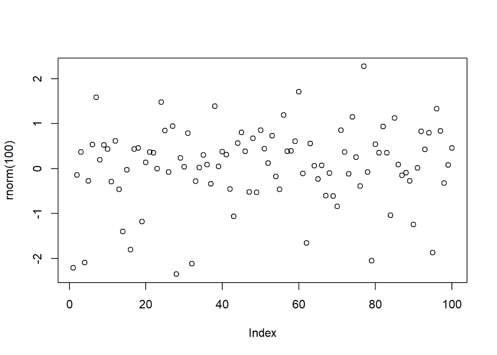

```r
plot(rnorm(100))
```

## 4

Find help for the sqrt function.

```r
help(sqrt)#=?sqrt
```

```
## starting httpd help server ... done
```

## 5

Make a file called firstscript.R containing Rcode that generates 100 random numbers and plots them, and run this script several times.

```r
source("firstscript.R")
```

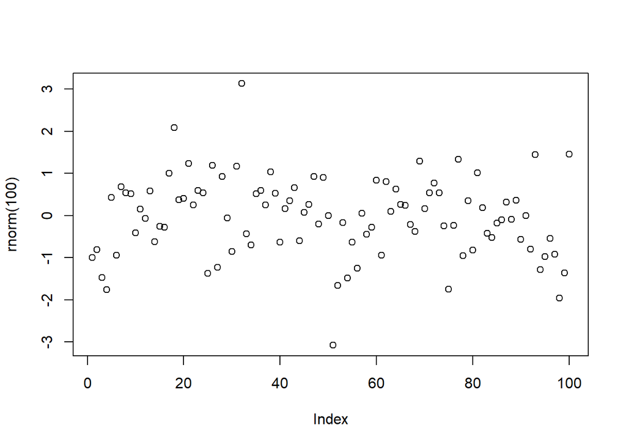

```r
source("firstscript.R")
```

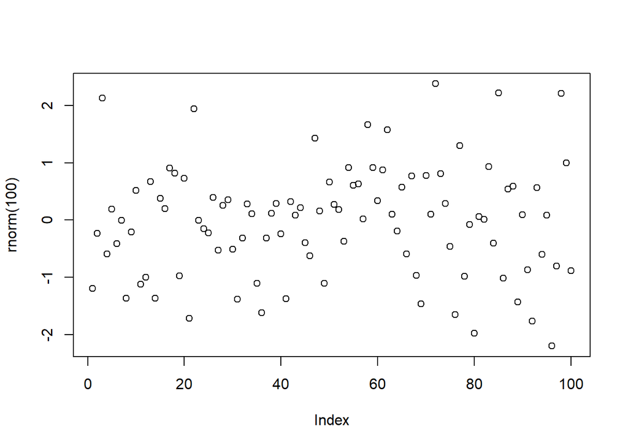

```r
source("firstscript.R")
```

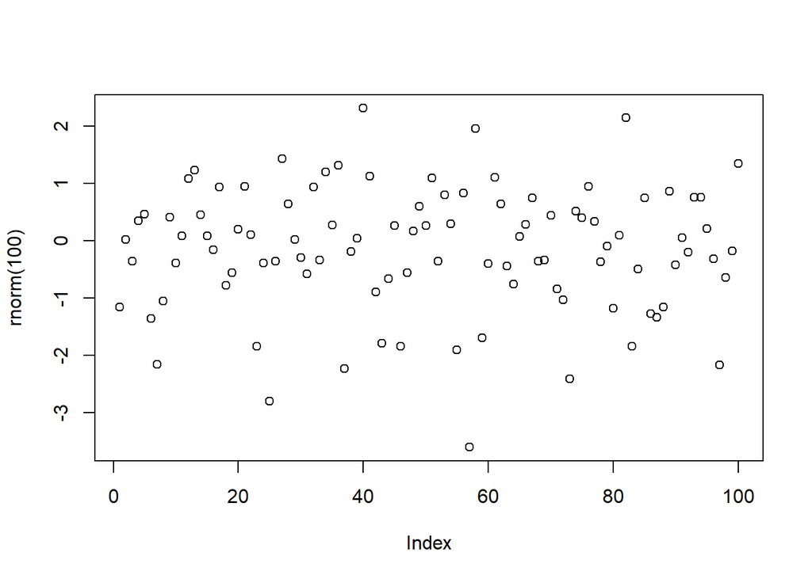

# 6.2

Put the numbers 31 to 60 in a vector named P and in a matrix with 6 rows and 5 columns named Q. Tip: use the function seq. Look at the different ways scalars, vectors and matrices are denoted in the workspace window.

```r
P<-seq(from=31,to=60,by=1)
P
```

```
##  [1] 31 32 33 34 35 36 37 38 39 40 41 42 43 44 45 46 47 48 49 50 51 52 53
## [24] 54 55 56 57 58 59 60
```

```r
Q<-matrix(data=P,nrow=6,ncol=5)#by colume
Q
```

```
##      [,1] [,2] [,3] [,4] [,5]
## [1,]   31   37   43   49   55
## [2,]   32   38   44   50   56
## [3,]   33   39   45   51   57
## [4,]   34   40   46   52   58
## [5,]   35   41   47   53   59
## [6,]   36   42   48   54   60
```

```r
Q2<-matrix(data=P,nrow=6,ncol=5,byrow=TRUE)#by row
Q2
```

```
##      [,1] [,2] [,3] [,4] [,5]
## [1,]   31   32   33   34   35
## [2,]   36   37   38   39   40
## [3,]   41   42   43   44   45
## [4,]   46   47   48   49   50
## [5,]   51   52   53   54   55
## [6,]   56   57   58   59   60
```

## 6.3

Make a script file which constructs three random normal vectors of length 100. Call these vectors x1, x2 and x3. Make a data frame called t with three columns (called a, b and c) containing respectively x1, x1+x2 and x1+x2+x3. Call plot(t) for this data frame.

```r
x1<-rnorm(100)
x2<-rnorm(100)
x3<-rnorm(100)
t=data.frame(a=x1,b=x1+x2,c=x1+x2+x3)
t
```

```
##               a            b            c
## 1   -1.95150757 -2.157829982 -1.615312960
## 2    1.75294526 -0.099097370  0.046398755
## 3   -0.17729276 -1.123047708  1.511719653
## 4   -0.55237378 -0.728116517 -1.495514990
## 5   -2.41073570 -3.339015202 -2.672641397
## 6    0.18443882  0.038118004 -0.784707439
## 7    0.24285378  0.510258048  1.434872796
## 8   -0.65214933 -1.362607576 -2.055350000
## 9    1.00845294 -0.162077050 -0.876616195
## 10  -1.43834740 -1.058409440  0.032715232
## 11  -0.72091118  0.010315226  0.468809210
## 12   1.80709622  2.995139842  1.729152762
## 13   0.48254048  1.402627865  0.272072178
## 14   0.80806981  2.244664726  2.131491313
```

[output cut: 86 more lines]

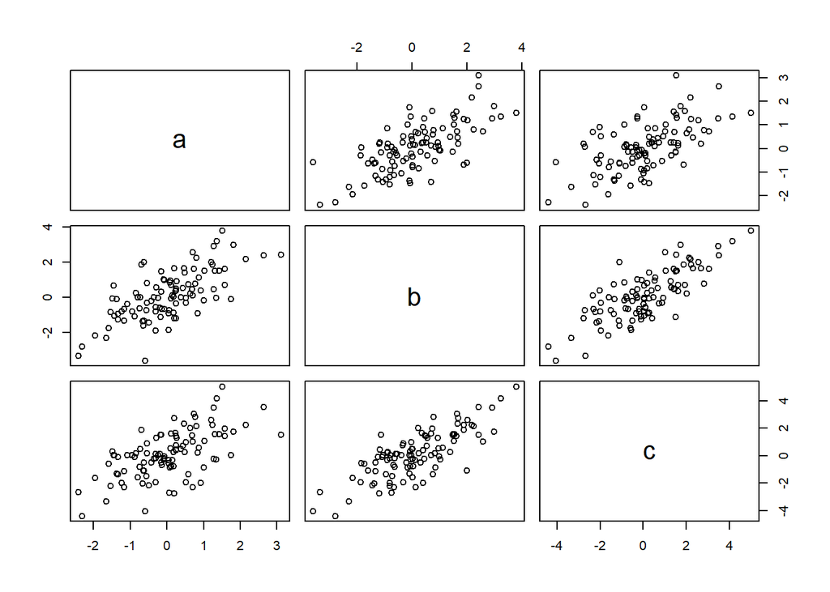

```r
plot(t)
```

## 7

Add these lines to the script file of the previous section. Try to find out, either by experimenting or by using the help, what the meaning is of rgb, the last argument of rgb, lwd, pch, cex

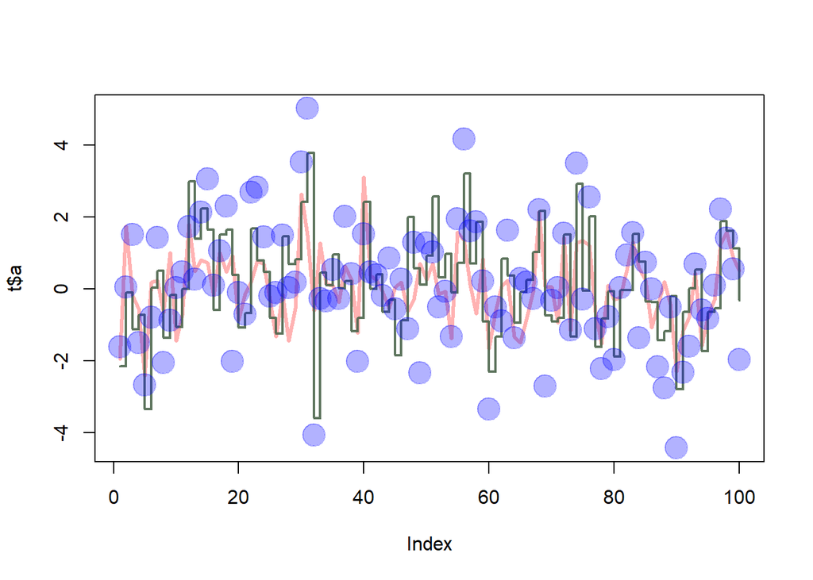

```r
plot(t$a, type="l", ylim=range(t),
lwd=3, col=rgb(1,0,0,0.3))
lines(t$b, type="s", lwd=2,
col=rgb(0.3,0.4,0.3,0.9))
points(t$c, pch=20, cex=4,
 col=rgb(0,0,1,0.3))
```

### col(rgb)=線條顏色及深淺

### the last argument of rgb=透明度

### type=圖表形式,ylim=y軸座標最小值

## 8

Make a file called tst1.txt in Notepad from the example in Figure 4 and store it in your working directory. Write a script to read it, to multiply the column called g by 5 and to store it as tst2.txt

```r
d = data.frame(a = c(1,2,4,8,16,32), g = c(2,4,8,16,32,64),x=c(3,6,12,24,48,96))
d
```

```
##    a  g  x
## 1  1  2  3
## 2  2  4  6
## 3  4  8 12
## 4  8 16 24
## 5 16 32 48
## 6 32 64 96
```

```r
write.table(d, file="tst1.txt",row.names=FALSE)
d2 = read.table(file="tst1.txt",header=TRUE)
d2$g=d2$g*5
write.table(d2, file="tst2.txt",row.names=FALSE)
d2
```

```
##    a   g  x
## 1  1  10  3
## 2  2  20  6
## 3  4  40 12
## 4  8  80 24
## 5 16 160 48
## 6 32 320 96
```

## 9

Compute the mean of the square root of a vector of 100 random numbers. What happens?

```r
a=rnorm(100)
a
```

```
##   [1]  0.17646926  0.43710666  0.53864541 -0.48476804  0.48967474
##   [6] -0.44226429  0.07550336  0.06705209  1.64620577 -0.45865662
##  [11]  0.02960859  0.33237074 -0.82411427 -0.96507423 -1.42433826
##  [16] -0.84337094  0.60984188  0.05892792  0.46735651  0.57230436
##  [21]  2.16355647 -0.47380642 -1.25358949  0.54495396  2.06867703
##  [26] -0.86288079  0.19075596 -1.80750516 -1.09111740 -0.15879435
##  [31]  0.36024171  0.52588272 -1.14343541 -0.13079623  1.30542675
##  [36] -0.27804738  0.01750402  0.10727701  0.08326196 -0.27518732
##  [41]  1.46762732 -0.43203630  1.89199771 -0.28342161  0.44998347
##  [46]  1.68757444  2.17627962 -0.97273180 -0.81427508  0.93721080
##  [51] -0.03243153  1.08568217  1.23138038 -0.94626667 -1.39450559
##  [56]  0.02959059 -0.15865676 -0.51122595 -0.08403089  0.32327270
##  [61]  2.72651605 -1.16445952 -0.34764925  0.49433180 -1.09261215
##  [66] -2.19858882  1.10268894 -0.61943959 -0.08614844 -0.44527381
##  [71]  1.01233886  0.34580925  0.05353600  1.41781926 -0.60400651
##  [76]  1.04711825 -1.60644060 -0.86467660  0.35418054  0.10807614
##  [81]  0.84835609  0.27537722 -1.60684089  1.50587113  0.91551830
##  [86] -1.11359516 -0.75658960 -0.20451223 -1.37436693  2.90330713
##  [91]  0.16670326  0.54956464 -1.48904384 -0.16015919 -0.02875143
##  [96] -1.22916341 -1.29953675  0.36194831  1.45662033  0.47128538
```

```r
b=sqrt(a)
b
```

```
##   [1] 0.4200824 0.6611404 0.7339247       NaN 0.6997676       NaN 0.2747787
##   [8] 0.2589442 1.2830455       NaN 0.1720715 0.5765160       NaN       NaN
##  [15]       NaN       NaN 0.7809237 0.2427507 0.6836348 0.7565080 1.4709033
##  [22]       NaN       NaN 0.7382100 1.4382896       NaN 0.4367562       NaN
##  [29]       NaN       NaN 0.6002014 0.7251777       NaN       NaN 1.1425527
##  [36]       NaN 0.1323028 0.3275317 0.2885515       NaN 1.2114567       NaN
##  [43] 1.3754991       NaN 0.6708081 1.2990668 1.4752219       NaN       NaN
##  [50] 0.9680965       NaN 1.0419607 1.1096758       NaN       NaN 0.1720192
##  [57]       NaN       NaN       NaN 0.5685708 1.6512165       NaN       NaN
##  [64] 0.7030873       NaN       NaN 1.0500900       NaN       NaN       NaN
##  [71] 1.0061505 0.5880555 0.2313785 1.1907222       NaN 1.0232880       NaN
##  [78]       NaN 0.5951307 0.3287494 0.9210625 0.5247640       NaN 1.2271394
##  [85] 0.9568272       NaN       NaN       NaN       NaN 1.7039094 0.4082931
##  [92] 0.7413263       NaN       NaN       NaN       NaN       NaN 0.6016214
##  [99] 1.2069053 0.6865023
```

```r
c=mean(b)
c
```

```
## [1] NaN
```

the answer is Nan

## 10.2

Make a graph with on the x-axis: today, Sinterklaas2017 and your next birthday and on the y-axis the number of presents you expect on each of thesedays. Tip: make two vectors first.

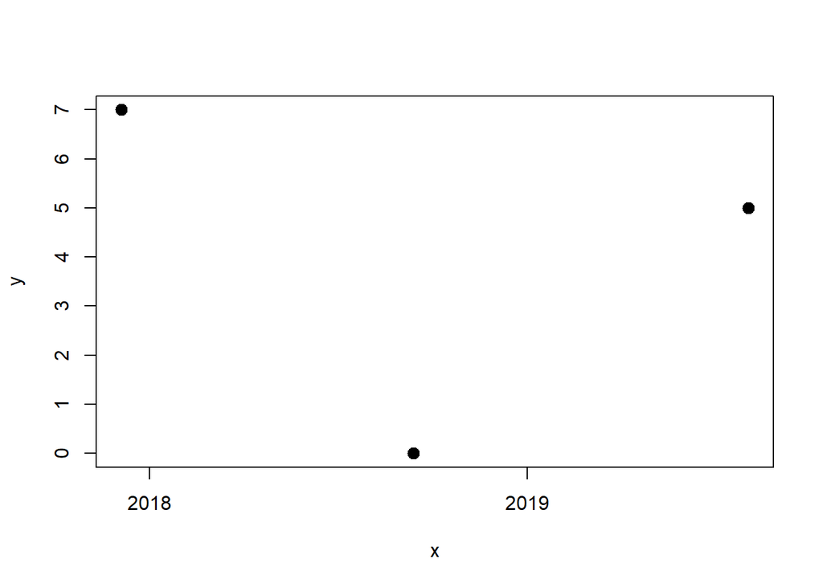

```r
x=strptime(c("20180913","20171205","20190802"),format="%Y%m%d")
y=c(0,7,5)
plot(x=x,y=y,pch=20,cex=2)
```

## 11.2

Make a vector from 1 to 100. Make a for-loop which runs through the whole vector. Multiply the elements which are smaller than 5 and larger than 90 with 10 and the other elements with 0.1

```r
h=seq(from=1,to=100)
s=c()
for (i in 1:length(h))
{
  if(h[i]<5|h[i]>90)
  {
    s[i]=h[i]*10
  }else{
    s[i]=h[i]*0.1
  }
}
s
```

```
##   [1]   10.0   20.0   30.0   40.0    0.5    0.6    0.7    0.8    0.9    1.0
##  [11]    1.1    1.2    1.3    1.4    1.5    1.6    1.7    1.8    1.9    2.0
##  [21]    2.1    2.2    2.3    2.4    2.5    2.6    2.7    2.8    2.9    3.0
##  [31]    3.1    3.2    3.3    3.4    3.5    3.6    3.7    3.8    3.9    4.0
##  [41]    4.1    4.2    4.3    4.4    4.5    4.6    4.7    4.8    4.9    5.0
##  [51]    5.1    5.2    5.3    5.4    5.5    5.6    5.7    5.8    5.9    6.0
##  [61]    6.1    6.2    6.3    6.4    6.5    6.6    6.7    6.8    6.9    7.0
##  [71]    7.1    7.2    7.3    7.4    7.5    7.6    7.7    7.8    7.9    8.0
##  [81]    8.1    8.2    8.3    8.4    8.5    8.6    8.7    8.8    8.9    9.0
##  [91]  910.0  920.0  930.0  940.0  950.0  960.0  970.0  980.0  990.0 1000.0
```

## 11.3

Write a function for the previous ToDo, so that you can feed it any vector you like (as argument). Use a for-loop in the function to do the computation with each element. Use the standard R function length in the specification of the counter.

```r
fun1=function(h)
{
  s=c()
  for (i in 1:length(h))
  {
    if(h[i]<5|h[i]>90)
    {
      s[i]=h[i]*10
    }else{
      s[i]=h[i]*0.1
    }
  }
  return(s)
}

#test
h=seq(from=-5,to=100)
fun1(h)
```

```
##   [1]  -50.0  -40.0  -30.0  -20.0  -10.0    0.0   10.0   20.0   30.0   40.0
##  [11]    0.5    0.6    0.7    0.8    0.9    1.0    1.1    1.2    1.3    1.4
##  [21]    1.5    1.6    1.7    1.8    1.9    2.0    2.1    2.2    2.3    2.4
##  [31]    2.5    2.6    2.7    2.8    2.9    3.0    3.1    3.2    3.3    3.4
##  [41]    3.5    3.6    3.7    3.8    3.9    4.0    4.1    4.2    4.3    4.4
##  [51]    4.5    4.6    4.7    4.8    4.9    5.0    5.1    5.2    5.3    5.4
##  [61]    5.5    5.6    5.7    5.8    5.9    6.0    6.1    6.2    6.3    6.4
##  [71]    6.5    6.6    6.7    6.8    6.9    7.0    7.1    7.2    7.3    7.4
##  [81]    7.5    7.6    7.7    7.8    7.9    8.0    8.1    8.2    8.3    8.4
##  [91]    8.5    8.6    8.7    8.8    8.9    9.0  910.0  920.0  930.0  940.0
## [101]  950.0  960.0  970.0  980.0  990.0 1000.0
```